# Descriptive analyses: mental health and multimorbidity

OSEAS MACHADO GOMES** oseasmachado@gmail.com

22 November, 2021

# Introdução

Esse relatório apresenta uma análise descritiva da Base de dados SIH-BA (Sistema de Informação hospitalar do Estado da Bahia). Após ser extraída, a base do Sistema SIHD2-SUS cedida pelo SUREGS/SESAB é copiada pelo NPD (Núcleo de Produção de Dados) para o ambiente de produção onde o arquivo será manipulado de acordo com os procedimentos solicitados, assim como tratado e preparado para linkage. A versão a ser tratada aqui é SIHD2 (Sistema de Informação Hospitalar Versão 2) em vigor desde janeiro de 2008, referente ao estado na Bahia no período de 01/2008 a 03/2017. Os dados utilizados nessa primeira etapa referem-se a hospitalizações de pacientes diagnosticados por algum tipo de transtorno mental residentes no Estado da Bahia

# Análise dos dados

Incialmente foi realizada uma manipulação na base de dados do SIH-BA considerando variáveis de interesse para o estudo. Estatísticas descritivas foram utilizadas para cada variável para identificar suas características. As variáveis contínuas foram analisadas com as medidas descritivas media, mediana, mínimo máximo e desvio padrão (dp) e as variáveis categóricas foram descritas com o total de observações e suas correspondentes porcentagens.

## Testes Estatísticos

Os p-valores apresentado nas tabelas referem-se ao teste de qui - quadrado de independência para variáveis categóricas e análise de variâncias (ANOVA) para variáveis contínuas. Todas as análises foram feitas após correção das iah e retirada das duplicatas.

## Software utilizado nas análises

Todas as análises foram realizadas utilizando o software estatístico R. R Core Team (2021). R: A language and environment for statistical computing. R Foundation for Statistical Computing, Vienna, Austria. URL https://www.R-project.org/.

# Inspeção dos dados

Linkage: tratamento e preparação

- SIHD2-SUS
- Conversão para csv
- Criação do dicionário do CIDACS
- Padronização das variáveis
- Correção das variáveis string para linkage
- Extração para linkage

# Base de dados

- SIH-BA e Cadúnico (N = + 114 milhões)
- BA: N = 2407424
- Idade 0-112
- Périodo do estudo: 2008-2017
- Duplicatas: NPD
- Repetições por internação
- Dados faltantes

# Variáveis sociodemográficas da base

- Sexo
- Idade
- Raça/Cor
- Escolaridade
- Estado Civil

# OS DADOS APRESENTADOS NESTE RELATÓRIO SÃO DE PESSOAS MENORES DE 40 ANOS

# Tabela 7 - Tabela descritiva dos pacientes internados por doenças (Clínicas cronicas, Psyquiátrica e Clinicas) < 40 anos

|  | (0, 9] (N=388905) | (10, 20] (N=353350) | (21, 28] (N=387443) | (29, 39] (N=354746) | Total (N=1484444) | P-value |
| --- | --- | --- | --- | --- | --- | --- |
| factor(ah_paciente_sexo) |  |  |  |  |  |  |
| Masculino | 220257 (56.6%) | 98088 (27.8%) | 68347 (17.6%) | 85100 (24.0%) | 471792 (31.8%) | <0.001 |
| Feminino | 168648 (43.4%) | 255262 (72.2%) | 319096 (82.4%) | 269646 (76.0%) | 1012652 (68.2%) |  |
| factor(ah_paciente_raca_cor) |  |  |  |  |  |  |
| Branca | 27858 (7.2%) | 22795 (6.5%) | 25038 (6.5%) | 21309 (6.0%) | 97000 (6.5%) | <0.001 |
| Preta | 204972 (52.7%) | 180025 (50.9%) | 196940 (50.8%) | 180154 (50.8%) | 762091 (51.3%) |  |
| Amarela | 2006 (0.5%) | 3225 (0.9%) | 3849 (1.0%) | 3374 (1.0%) | 12454 (0.8%) |  |
| Indigena | 203 (0.1%) | 131 (0.0%) | 108 (0.0%) | 100 (0.0%) | 542 (0.0%) |  |
| Missing | 153866 (39.6%) | 147174 (41.7%) | 161508 (41.7%) | 149809 (42.2%) | 612357 (41.3%) |  |
| factor(escolaridade_eq) |  |  |  |  |  |  |
| Nunca frequentou | 330679 (85.0%) | 48257 (13.7%) | 15400 (4.0%) | 38799 (10.9%) | 433135 (29.2%) | <0.001 |
| Pré-escola | 24479 (6.3%) | 11918 (3.4%) | 626 (0.2%) | 749 (0.2%) | 37772 (2.5%) |  |
| Alfabetização | 8040 (2.1%) | 15287 (4.3%) | 1436 (0.4%) | 2555 (0.7%) | 27318 (1.8%) |  |
| Ensino fundamental I | 13149 (3.4%) | 144346 (40.9%) | 91027 (23.5%) | 108076 (30.5%) | 356598 (24.0%) |  |
| Ensino fundamental II | 1008 (0.3%) | 76986 (21.8%) | 132666 (34.2%) | 79388 (22.4%) | 290048 (19.5%) |  |
| Ensino médio | 180 (0.0%) | 21129 (6.0%) | 71348 (18.4%) | 61716 (17.4%) | 154373 (10.4%) |  |
| Superior | 4 (0.0%) | 127 (0.0%) | 895 (0.2%) | 1877 (0.5%) | 2903 (0.2%) |  |
| Missing | 11366 (2.9%) | 35300 (10.0%) | 74045 (19.1%) | 61586 (17.4%) | 182297 (12.3%) |  |
| factor(ah_car_internacao) |  |  |  |  |  |  |
| Eletivo | 27158 (7.0%) | 24564 (7.0%) | 43075 (11.1%) | 64270 (18.1%) | 159067 (10.7%) | <0.001 |
| Outros tipos de acidente de trânsito | 362 (0.1%) | 766 (0.2%) | 735 (0.2%) | 782 (0.2%) | 2645 (0.2%) |  |
| Outros tipos de lesões e envenenamento por agentes quìmicos ou físicos | 1018 (0.3%) | 1515 (0.4%) | 955 (0.2%) | 1162 (0.3%) | 4650 (0.3%) |  |
| Urgência | 360367 (92.7%) | 326505 (92.4%) | 342678 (88.4%) | 288532 (81.3%) | 1318082 (88.8%) |  |
| factor(ah_modalidade_internacao) |  |  |  |  |  |  |
| Hospitalar | 387625 (99.7%) | 352913 (99.9%) | 387176 (99.9%) | 354329 (99.9%) | 1482043 (99.8%) | <0.001 |
| Hospitalar dia | 1252 (0.3%) | 342 (0.1%) | 141 (0.0%) | 228 (0.1%) | 1963 (0.1%) |  |
| Internacao domiciliar | 14 (0.0%) | 26 (0.0%) | 61 (0.0%) | 60 (0.0%) | 161 (0.0%) |  |
| Missing | 14 (0.0%) | 69 (0.0%) | 65 (0.0%) | 129 (0.0%) | 277 (0.0%) |  |
| factor(ah_mot_saida) |  |  |  |  |  |  |
| Permanência por intercorrência | 14826 (3.8%) | 18830 (5.3%) | 24400 (6.3%) | 26307 (7.4%) | 84363 (5.7%) | <0.001 |
| Permanência por impossibilidade sócio-familiar | 351123 (90.3%) | 201908 (57.1%) | 190580 (49.2%) | 210363 (59.3%) | 953974 (64.3%) |  |
| Permanência por processo de doação de órgaos | 3862 (1.0%) | 2250 (0.6%) | 2642 (0.7%) | 2901 (0.8%) | 11655 (0.8%) |  |
| Permanência por mudança de procedimento | 5606 (1.4%) | 3768 (1.1%) | 2093 (0.5%) | 2698 (0.8%) | 14165 (1.0%) |  |
| Permanência por reoperacao | 844 (0.2%) | 704 (0.2%) | 913 (0.2%) | 968 (0.3%) | 3429 (0.2%) |  |
| Permanência por outros motivos | 13 (0.0%) | 9644 (2.7%) | 13505 (3.5%) | 5899 (1.7%) | 29061 (2.0%) |  |
| Transferência para internação domiciliar | 875 (0.2%) | 730 (0.2%) | 824 (0.2%) | 876 (0.2%) | 3305 (0.2%) |  |
| Transferência para outro estabelecimento | 1 (0.0%) | 16 (0.0%) | 44 (0.0%) | 85 (0.0%) | 146 (0.0%) |  |
| Óbito com declaração fornecida pelo médico assistente | 923 (0.2%) | 998 (0.3%) | 1026 (0.3%) | 1467 (0.4%) | 4414 (0.3%) |  |
| Óbito com declaração fornecida pelo instituto médico legal-iml | 373 (0.1%) | 1025 (0.3%) | 1282 (0.3%) | 1732 (0.5%) | 4412 (0.3%) |  |
| Óbito com declaração fornecida pelo servico de verificação de óbito-SVO | 3 (0.0%) | 35 (0.0%) | 55 (0.0%) | 66 (0.0%) | 159 (0.0%) |  |
| Encerramento administrativo | 1 (0.0%) | 3 (0.0%) | 2 (0.0%) | 1 (0.0%) | 7 (0.0%) |  |
| Alta da mãe/puérpera e do recém-nascido | 17 (0.0%) | 46 (0.0%) | 48 (0.0%) | 48 (0.0%) | 159 (0.0%) |  |
| Alta da mãe/puérpera e permanência do recém-nascido | 1370 (0.4%) | 1033 (0.3%) | 797 (0.2%) | 1090 (0.3%) | 4290 (0.3%) |  |
| Alta da mãe/puérpera e Óbito do recém-nascido | 639 (0.2%) | 1174 (0.3%) | 1267 (0.3%) | 1366 (0.4%) | 4446 (0.3%) |  |
| Alta da mãe/puérpera e Óbito fetal | 23 (0.0%) | 98 (0.0%) | 140 (0.0%) | 167 (0.0%) | 428 (0.0%) |  |
| Obito da mãe/puérpera e Óbito do recém-nascido | 5361 (1.4%) | 4923 (1.4%) | 4513 (1.2%) | 4964 (1.4%) | 19761 (1.3%) |  |
| Missing | 3045 (0.8%) | 106165 (30.0%) | 143312 (37.0%) | 93748 (26.4%) | 346270 (23.3%) |  |
| qtd_pessoas_fam_renda |  |  |  |  |  |  |
| Mean (SD) | 3.84 (1.89) | 3.55 (1.71) | 3.34 (1.73) | 3.10 (1.64) | 3.46 (1.77) | <0.001 |
| Median [Min, Max] | 3.00 [1.00, 27.0] | 3.00 [1.00, 22.0] | 3.00 [1.00, 22.0] | 3.00 [1.00, 22.0] | 3.00 [1.00, 27.0] |  |
| renda_tot_fam_mds |  |  |  |  |  |  |
| Mean (SD) | 101 (220) | 29.3 (139) | 37.1 (236) | 61.4 (243) | 57.8 (216) | <0.001 |
| Median [Min, Max] | 2.00 [0, 20100] | 0 [0, 7680] | 0 [0, 93600] | 1.00 [0, 52900] | 1.00 [0, 93600] |  |
| Missing | 1930 (0.5%) | 237 (0.1%) | 389 (0.1%) | 334 (0.1%) | 2890 (0.2%) |  |
| renda_percapita_mds |  |  |  |  |  |  |
| Mean (SD) | 25.5 (56.6) | 9.13 (43.1) | 13.4 (98.8) | 23.5 (92.9) | 18.0 (77.1) | <0.001 |
| Median [Min, Max] | 0.500 [0, 5030] | 0 [0, 2410] | 0 [0, 46800] | 0.250 [0, 8820] | 0.250 [0, 46800] |  |
| Missing | 1930 (0.5%) | 237 (0.1%) | 389 (0.1%) | 334 (0.1%) | 2890 (0.2%) |  |
| factor(cd_estado_civil) |  |  |  |  |  |  |
| Solteiro(a) | 204726 (52.6%) | 295062 (83.5%) | 279270 (72.1%) | 217023 (61.2%) | 996081 (67.1%) | <0.001 |
| Casado(a) | 2 (0.0%) | 2441 (0.7%) | 24945 (6.4%) | 58453 (16.5%) | 85841 (5.8%) |  |
| Divorciado(a) | 0 (0%) | 18 (0.0%) | 81 (0.0%) | 455 (0.1%) | 554 (0.0%) |  |
| Separado(a) | 1 (0.0%) | 63 (0.0%) | 1081 (0.3%) | 3970 (1.1%) | 5115 (0.3%) |  |
| Viúvo(a) | 0 (0%) | 8 (0.0%) | 105 (0.0%) | 683 (0.2%) | 796 (0.1%) |  |
| Missing | 184176 (47.4%) | 55758 (15.8%) | 81961 (21.2%) | 74162 (20.9%) | 396057 (26.7%) |  |
| as.numeric(dias_internacao) |  |  |  |  |  |  |
| Mean (SD) | 3.46 (20.9) | 2.93 (7.55) | 2.85 (8.17) | 3.43 (11.2) | 3.17 (13.2) | <0.001 |
| Median [Min, Max] | 2.00 [0, 11200] | 2.00 [0, 1550] | 2.00 [0, 1460] | 2.00 [0, 2930] | 2.00 [0, 11200] |  |
| factor(ah_diag_pri_DC) |  |  |  |  |  |  |
| 0 | 340264 (87.5%) | 334689 (94.7%) | 370132 (95.5%) | 324943 (91.6%) | 1370028 (92.3%) | <0.001 |
| 1 | 48592 (12.5%) | 18008 (5.1%) | 15298 (3.9%) | 26488 (7.5%) | 108386 (7.3%) |  |
| 2 | 49 (0.0%) | 653 (0.2%) | 2013 (0.5%) | 3315 (0.9%) | 6030 (0.4%) |  |

# Densidade das idades (doenças clinicas + cronicas clinicas + psyquiatrica)

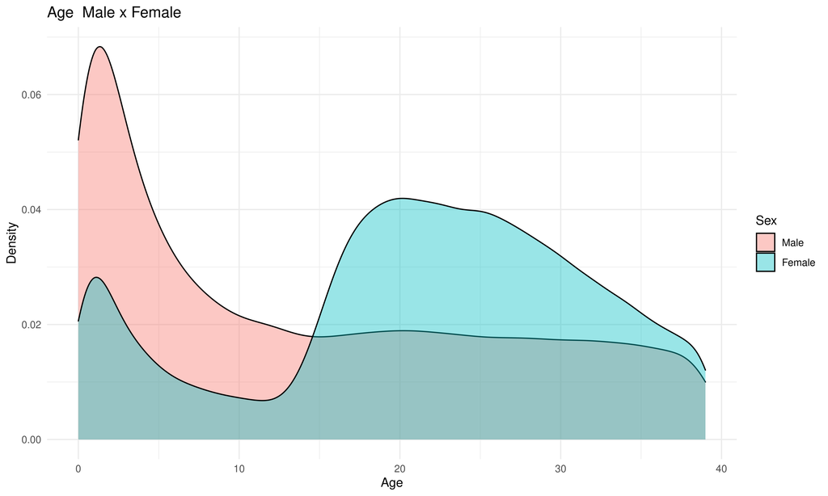

# Densidade somente doenças cronicas(Clinicas cronicas + Fs)

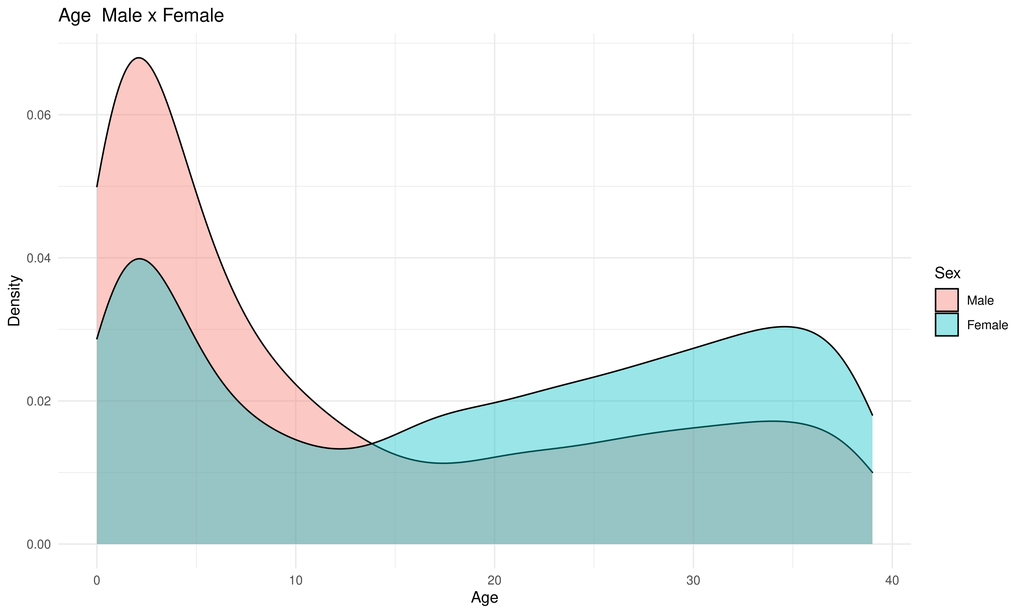